# Tugas MPDW_Model Arima

Rahma Annisa

# Deadline: kamis, 1 oktober 2026 (23.59)

# Data

- Nama *Dataset*: Data Historis Harian Saham Spotify
- Karakteristik Data: Deret waktu univariat harian (*daily time series*).
- Periode Amatan: 3 Januari 2023 hingga 28 Agustus 2026.
- Jumlah Pengamatan: Sebanyak 917 amatan (memenuhi batas minimal tugas, yaitu minimal 500 amatan).
- Variabel yang Dianalisis: Harga penutupan harian (*Close price*).
- Tujuan Analisis: Membangun model peramalan terbaik menggunakan metodologi Box-Jenkins (ARIMA) melalui tahapan pembagian data latih dan uji (*train and test split*), uji kestasioneran ragam dan rataan, identifikasi ordo model, pendugaan parameter, uji diagnostik sisaan (*diagnostic checking*), *overfitting*, serta evaluasi akurasi hasil peramalan (*forecasting*).

# Library

```r
library(readxl)
library(forecast)
library(tseries)
library(TSA)
library(lmtest)
```

```r
library(ggplot2)
```

## Keterangan Library:

- library `readxl` digunakan untuk membaca berkas data apabila formatnya berupa *Excel* (`.xlsx` atau `.xls`).
- library`forecast` digunakan untuk fungsi utama pemodelan deret waktu, pembentukan model ARIMA, penentuan nilai *lambda* *Box-Cox*, transformasi, serta pembuatan proyeksi peramalan (*forecasting*).
- library `tseries` digunakan untuk pengujian formal kestasioneran data melalui uji *Augmented Dickey-Fuller* (ADF) dan uji kenormalan sisaan *Jarque-Bera*.
- library `TSA` digunakan untuk menampilkan matriks *Extended Autocorrelation Function* (EACF) guna mempermudah penentuan kandidat ordo model ARIMA.
- library `lmtest` menyediakan fungsi uji signifikansi individual parameter model deret waktu (*coeftest*).
- library `ggplot2` digunakan untuk kebutuhan kustomisasi grafik visualisasi data deret waktu dan evaluasi hasil model.

# Impor Data

```r
data <- read.csv("E:/SPOT_daily_data_Rahma Annisa_M0401241092.csv", sep = ";", stringsAsFactors = FALSE)

head(data)
```

```
##                        Date                  Open                  High
## 1 2023-01-03 00:00:00-05:00 8.187.999.725.341.790 8.198.999.786.376.950
## 2 2023-01-04 00:00:00-05:00              83.00.00 8.337.000.274.658.200
## 3 2023-01-05 00:00:00-05:00 8.061.000.061.035.150 8.261.000.061.035.150
## 4 2023-01-06 00:00:00-05:00   826.500.015.258.789              84.25.00
## 5 2023-01-09 00:00:00-05:00 8.444.999.694.824.210 8.631.999.969.482.420
## 6 2023-01-10 00:00:00-05:00 8.486.000.061.035.150              91.00.00
##                     Low                 Close  Volume Dividends Stock.Splits
## 1 7.923.999.786.376.950   819.000.015.258.789 1286800         0            0
## 2 8.087.000.274.658.200 8.133.000.183.105.460 1842900         0            0
## 3 7.913.999.938.964.840 8.158.000.183.105.460 1557100         0            0
## 4   798.499.984.741.211 8.354.000.091.552.730 1185100         0            0
## 5 8.377.200.317.382.810 8.504.000.091.552.730 1376800         0            0
## 6 8.469.000.244.140.620 9.079.000.091.552.730 2044800         0            0
```

```r
str(data)
```

```
## 'data.frame':    917 obs. of  8 variables:
##  $ Date        : chr  "2023-01-03 00:00:00-05:00" "2023-01-04 00:00:00-05:00" "2023-01-05 00:00:00-05:00" "2023-01-06 00:00:00-05:00" ...
##  $ Open        : chr  "8.187.999.725.341.790" "83.00.00" "8.061.000.061.035.150" "826.500.015.258.789" ...
##  $ High        : chr  "8.198.999.786.376.950" "8.337.000.274.658.200" "8.261.000.061.035.150" "84.25.00" ...
##  $ Low         : chr  "7.923.999.786.376.950" "8.087.000.274.658.200" "7.913.999.938.964.840" "798.499.984.741.211" ...
##  $ Close       : chr  "819.000.015.258.789" "8.133.000.183.105.460" "8.158.000.183.105.460" "8.354.000.091.552.730" ...
##  $ Volume      : int  1286800 1842900 1557100 1185100 1376800 2044800 1631000 1774400 2135100 1752100 ...
##  $ Dividends   : num  0 0 0 0 0 0 0 0 0 0 ...
##  $ Stock.Splits: num  0 0 0 0 0 0 0 0 0 0 ...
```

## Keterangan Impor Data:

- Total data sebanyak 917 baris amatan dan 8 peubah
- Jumlah amatan tersebut telah memenuhi syarat tugas praktikum, yaitu minimal 500 amatan.
- Peubah yang termuat meliputi *Date*, *Open*, *High*, *Low*, *Close*, *Volume*, *Dividends*, dan *Stock Splits*
- Struktur data awal, peubah harga masih bertipe karakter (*character*) akibat format pemisah desimal dan ribuan, sehingga perlu pembersihan data.

# Pembersihan Data dan Eksplorasi Awal

```r
clean_num <- function(vec) {
  digits_only <- gsub("[^0-9]", "", vec)
  res <- numeric(length(vec))
  for (i in seq_along(digits_only)) {
    d <- digits_only[i]
    if (i == 1) {
      res[i] <- as.numeric(paste0(substr(d, 1, 2), ".", substr(d, 3, 6)))
    } else {
      prev <- res[i - 1]
      c2 <- as.numeric(paste0(substr(d, 1, 2), ".", substr(d, 3, 7)))
      c3 <- as.numeric(paste0(substr(d, 1, 3), ".", substr(d, 4, 8)))
      if (is.na(c2)) c2 <- c3
      if (is.na(c3)) c3 <- c2
      if (abs(c2 - prev) < abs(c3 - prev)) {
        res[i] <- c2
      } else {
        res[i] <- c3
      }
    }
  }
  return(res)
}

data$Close_clean <- clean_num(data$Close)
y <- ts(data$Close_clean)

head(data[, c("Date", "Close", "Close_clean")])
```

```
##                        Date                 Close Close_clean
## 1 2023-01-03 00:00:00-05:00   819.000.015.258.789       81.90
## 2 2023-01-04 00:00:00-05:00 8.133.000.183.105.460       81.33
## 3 2023-01-05 00:00:00-05:00 8.158.000.183.105.460       81.58
## 4 2023-01-06 00:00:00-05:00 8.354.000.091.552.730       83.54
## 5 2023-01-09 00:00:00-05:00 8.504.000.091.552.730       85.04
## 6 2023-01-10 00:00:00-05:00 9.079.000.091.552.730       90.79
```

```r
summary(y)
```

```
##    Min. 1st Qu.  Median    Mean 3rd Qu.    Max.
##   81.33  183.04  384.05  390.29  549.08  775.90
```

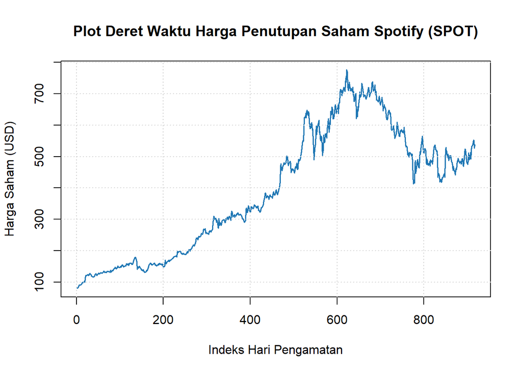

```r
plot(y,
     main = "Plot Deret Waktu Harga Penutupan Saham Spotify (SPOT)",
     ylab = "Harga Saham (USD)",
     xlab = "Indeks Hari Pengamatan",
     col = "#1f77b4",
     lwd = 1.5)
grid()
```

## Keterangan Pembersihan Data dan Eksplorasi Awal:

- Peubah harga penutupan awalnya bertipe karakter akibat format tanda titik, lalu dibersihkan menjadi format numerik riil
- Data yang sudah bersih diubah menjadi objek *time series* `y` dengan total 917 amatan harian
- Plot deret waktu memperlihatkan tren kenaikan harga yang kuat hingga mencapai puncak di atas 700 USD sebelum kembali berfluktuasi
- Keberadaan tren ini menunjukkan jika dilihat secara visual data belum stasioner dalam rataan

# Pemodelan ARIMA

## Tahap 1: Pembagian Data *Train* dan *Test*

```r
n <- length(y)
n_train <- round(0.80 * n)

train <- subset(y, end = n_train)
test  <- subset(y, start = n_train + 1)

length(train)
```

```
## [1] 734
```

```r
length(test)
```

```
## [1] 183
```

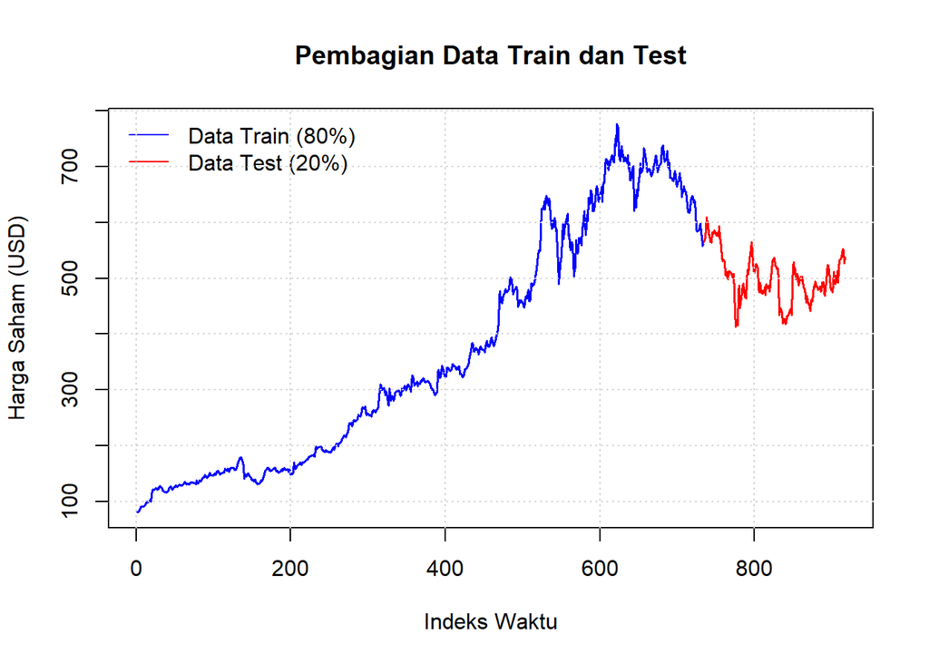

```r
plot(train, col = "blue", lwd = 1.5,
     main = "Pembagian Data Train dan Test",
     ylab = "Harga Saham (USD)", xlab = "Indeks Waktu",
     xlim = c(1, n), ylim = range(y))
lines((n_train + 1):n, test, col = "red", lwd = 1.5)
legend("topleft", legend = c("Data Train (80%)", "Data Test (20%)"),
       col = c("blue", "red"), lty = 1, bty = "n")
grid()
```

## Keterangan Pembagian Data *Train* dan *Test*:

- Data dibagi dengan proporsi 80% untuk data latih (*train*) dan 20% untuk data uji (*test*)
- Data *train* berjumlah 734 amatan pertama yang digunakan untuk pembentukan dan penaksiran model ARIMA
- Data *test* berjumlah 183 amatan terakhir yang digunakan untuk menguji performa hasil peramalan (*forecasting*)
- Visualisasi grafik menunjukkan garis biru sebagai data *train* dan garis merah sebagai data *test*

## Tahap 2: Uji Stasioneritas Ragam

```r
bc <- BoxCox.ar(train)
```

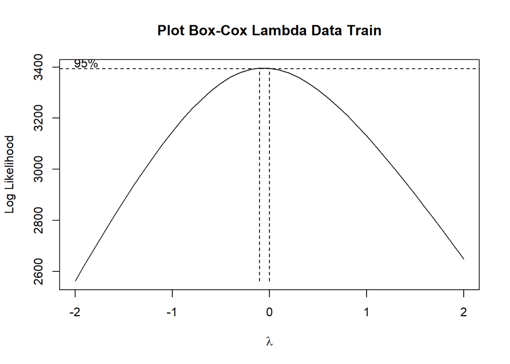

```r
title(main = "Plot Box-Cox Lambda Data Train")
```

```r
lambda_opt <- BoxCox.lambda(train)
lambda_opt
```

```
## [1] 0.05920164
```

## Keterangan Uji Stasioneritas Ragam:

- Pengujian kestasioneran ragam pada data *train* menghasilkan nilai *lambda* optimal sebesar 0.0592
- Garis putus-putus selang kepercayaan 95% berada di sekitar nilai 0 dan tidak memuat angka 1 ($1 \notin \text{CI}$)
- Karena nilai 1 berada di luar selang kepercayaan, maka ragam data *train* belum stasioner
- Oleh karena itu, data perlu ditransformasikan menggunakan metode *Box-Cox* dengan nilai *lambda* optimal tersebut sebelum melangkah ke pengujian rataan.

# Transformasi Ragam dan Uji Stasioneritas Rataan

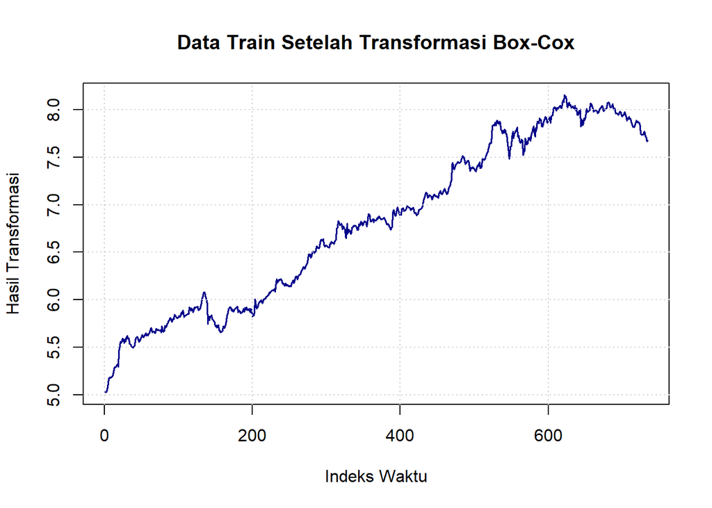

```r
train_bc <- BoxCox(train, lambda = lambda_opt)

plot(train_bc,
     main = "Data Train Setelah Transformasi Box-Cox",
     ylab = "Hasil Transformasi",
     xlab = "Indeks Waktu",
     col = "darkblue",
     lwd = 1.5)
grid()
```

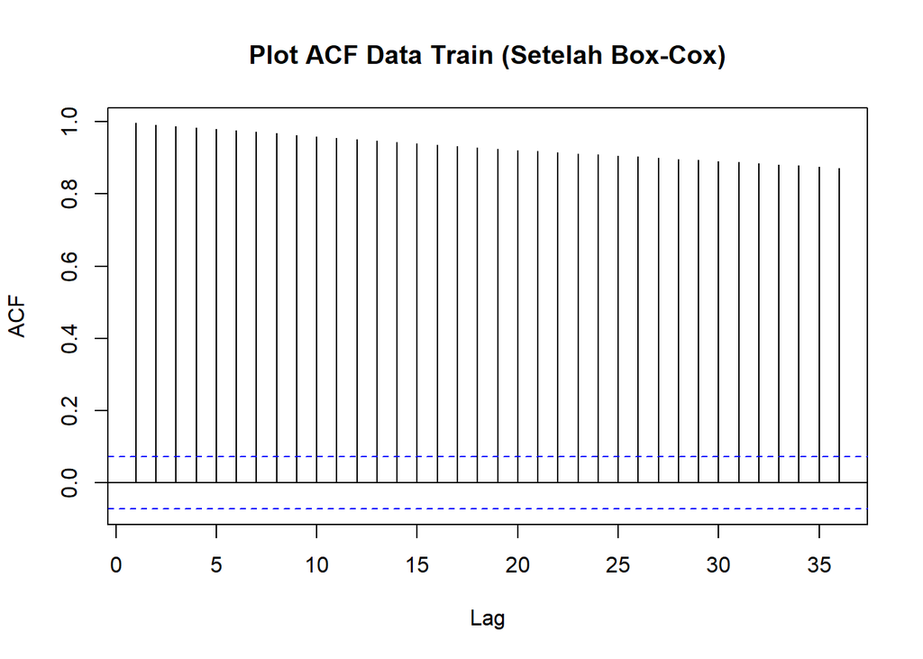

```r
acf(train_bc, lag.max = 36, main = "Plot ACF Data Train (Setelah Box-Cox)")
```

```r
adf.test(train_bc)
```

```
##
##  Augmented Dickey-Fuller Test
##
## data:  train_bc
## Dickey-Fuller = -1.6346, Lag order = 9, p-value = 0.733
## alternative hypothesis: stationary
```

## Keterangan Transformasi Ragam dan Uji Stasioneritas Rataan:

- Data *train* ditransformasikan menggunakan *Box-Cox* untuk menstabilkan ragam
- Plot ACF menunjukkan pola penurunan lambat (*slow decay*) yang menandakan data belum stasioner dalam rataan
- Uji *Augmented Dickey-Fuller* (ADF) menghasilkan *p-value* sebesar 0.733 > 0.05, sehingga gagal tolak $H_0$ (data belum stasioner dalam rataan)
- Maka diperlukan proses pembedaan untuk menstasionerkan rataan data.

## Tahap 3: Pembedaan (Differencing) dan Uji Stasioneritas

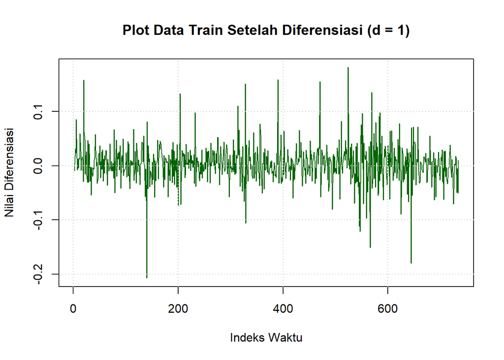

```r
train_diff <- diff(train_bc, differences = 1)

plot(train_diff,
     main = "Plot Data Train Setelah Diferensiasi (d = 1)",
     ylab = "Nilai Diferensiasi",
     xlab = "Indeks Waktu",
     col = "darkgreen")
grid()
```

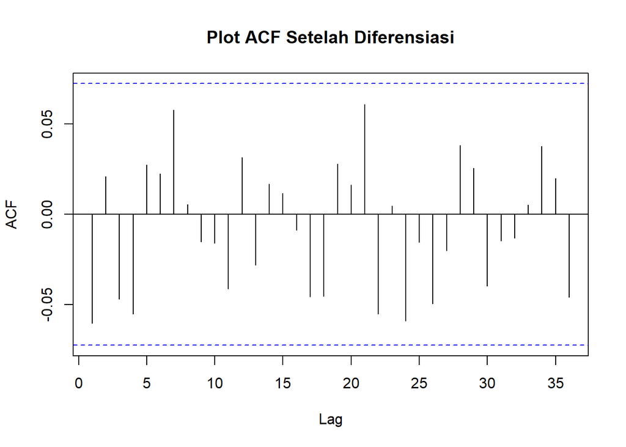

```r
acf(train_diff, lag.max = 36, main = "Plot ACF Setelah Diferensiasi")
```

```r
adf.test(train_diff)
```

```
##
##  Augmented Dickey-Fuller Test
##
## data:  train_diff
## Dickey-Fuller = -8.4694, Lag order = 9, p-value = 0.01
## alternative hypothesis: stationary
```

## Keterangan Pembedaan dan Uji Stasioneritas:

- Pembedaan pertama ($d = 1$) dilakukan untuk menghilangkan tren kenaikan, karena metode ARIMA mewajibkan data memiliki rataan yang stabil/stasioner
- Gerakan data di plot kini sudah datar dan stabil di sekitar angka nol
- Garis-garis pada plot ACF langsung berada di dalam batas garis biru (*cuts off*), yang menandakan hubungan panjang antaramatan sudah hilang dan rataan data sudah stasioner
- Nilai *p-value* uji ADF adalah 0.01 < 0.05, artinya data sudah terbukti stasioner dalam rataan
- Karena ragam dan rataan sudah stasioner, maka nilai diferensiasi yang digunakan adalah $d = 1$

## Tahap 4: Mengidentifikasi Model Tentatif

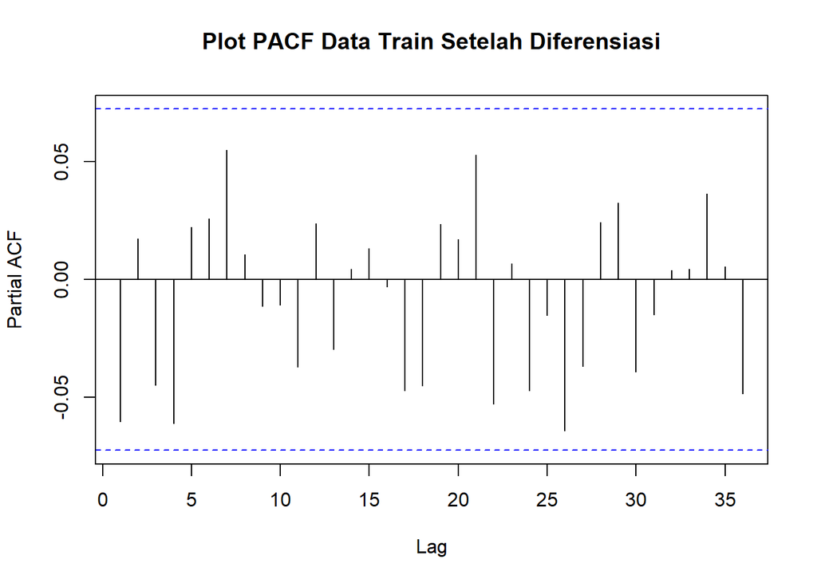

```r
pacf(train_diff, lag.max = 36, main = "Plot PACF Data Train Setelah Diferensiasi")
```

```r
eacf(train_diff)
```

```
## AR/MA
##   0 1 2 3 4 5 6 7 8 9 10 11 12 13
## 0 o o o o o o o o o o o  o  o  o
## 1 x o o o o o o o o o o  o  o  o
## 2 x x o o o o o o o o o  o  o  o
## 3 x x x o o o o o o o o  o  o  o
## 4 x x x x o o o o o o o  o  o  o
## 5 x o x x x o o o o o o  o  o  o
## 6 x x x x x o o o o o o  o  o  o
## 7 x x o x o o o o o o o  o  o  o
```

## Keterangan Identifikasi Model Tentatif:

- Plot PACF langsung terputus (*cuts off*) di dalam batas garis biru, mengindikasikan orde AR yang bernilai kecil ($p = 0$ atau $p = 1$)
- Matriks EACF menunjukkan ujung segitiga nol (*vertex of zeroes*) terbentuk mulai dari pasangan koordinat $(0,0)$, $(0,1)$, $(1,0)$, hingga $(1,1)$
- Berdasarkan pola EACF dan PACF dengan nilai pembedaan $d = 1$, model tentatif yang diidentifikasi adalah:
  1. $\text{ARIMA}(0,1,0)$
  2. $\text{ARIMA}(0,1,1)$
  3. $\text{ARIMA}(1,1,0)$
  4. $\text{ARIMA}(1,1,1)$
- Keempat model tentatif ini akan diestimasi parameternya untuk memilih model terbaik.

## Tahap 5: Pendugaan Parameter dan Pemilihan Model Terbaik

```r
# Pendugaan parameter masing-masing model tentatif
model1 <- Arima(train_bc, order = c(0, 1, 0))
model2 <- Arima(train_bc, order = c(0, 1, 1))
model3 <- Arima(train_bc, order = c(1, 1, 0))
model4 <- Arima(train_bc, order = c(1, 1, 1))

# Uji signifikansi parameter
coeftest(model2)
```

```
##
## z test of coefficients:
##
##      Estimate Std. Error z value Pr(>|z|)
## ma1 -0.046742   0.035955    -1.3   0.1936
```

```r
coeftest(model3)
```

```
##
## z test of coefficients:
##
##      Estimate Std. Error z value Pr(>|z|)
## ar1 -0.049316   0.036871 -1.3375   0.1811
```

```r
coeftest(model4)
```

```
##
## z test of coefficients:
##
##     Estimate Std. Error z value Pr(>|z|)
## ar1 -0.40341    0.36408 -1.1080   0.2678
## ma1  0.35136    0.36992  0.9498   0.3422
```

```r
# Perbandingan nilai AIC antar model
AIC(model1, model2, model3, model4)
```

```
##        df       AIC
## model1  1 -2810.730
## model2  2 -2810.421
## model3  2 -2810.517
## model4  3 -2809.129
```

## Keterangan Pendugaan Parameter dan Pemilihan Model Terbaik:

- Parameter AR dan MA pada Model 2, 3, dan 4 tidak signifikan ($p\text{-value} > 0.05$)
- Model 1 ($\text{ARIMA}(0,1,0)$) memiliki nilai AIC terendah, yaitu -2810.730
- Model 1 ($\text{ARIMA}(0,1,0)$) dipilih sebagai model terbaik karena paling sederhana dan memiliki AIC terkecil
- Model terpilih ini lanjut ke tahap uji diagnostik sisaan.

## Tahap 6: Uji Diagnostik Sisaan (Diagnostic Checking)

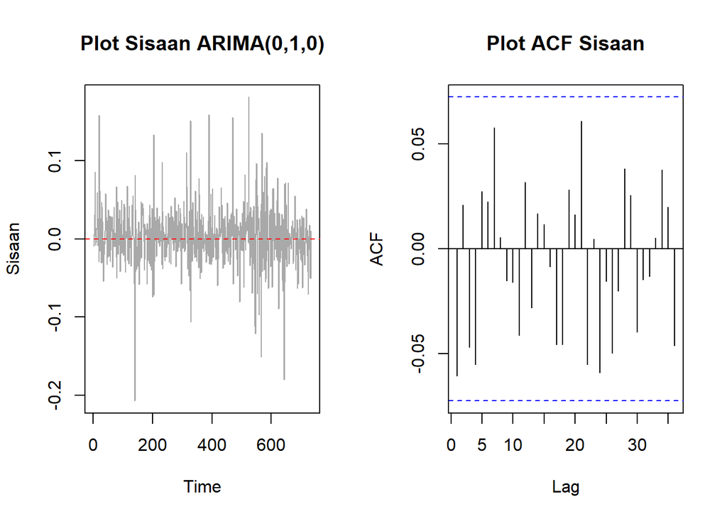

```r
sisaan <- residuals(model1)

par(mfrow = c(1, 2))
plot(sisaan, main = "Plot Sisaan ARIMA(0,1,0)", ylab = "Sisaan", col = "darkgray")
abline(h = 0, col = "red", lty = 2)

acf(sisaan, lag.max = 36, main = "Plot ACF Sisaan")
```

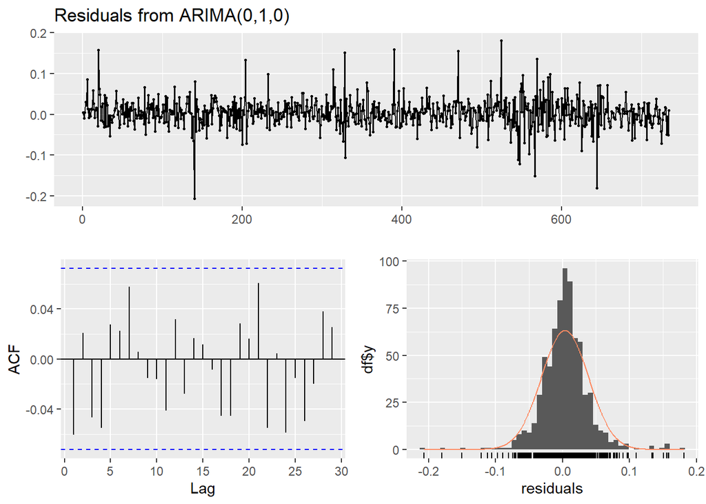

```
##
##  Ljung-Box test
##
## data:  Residuals from ARIMA(0,1,0)
## Q* = 10.659, df = 10, p-value = 0.3847
##
## Model df: 0.   Total lags used: 10
```

```r
par(mfrow = c(1, 1))

checkresiduals(model1)
```

```r
jarque.bera.test(sisaan)
```

```
##
##  Jarque Bera Test
##
## data:  sisaan
## X-squared = 1010.8, df = 2, p-value < 2.2e-16
```

```r
shapiro.test(sisaan[1:5000]) # jika n <= 5000
```

```
##
##  Shapiro-Wilk normality test
##
## data:  sisaan[1:5000]
## W = 0.92657, p-value < 2.2e-16
```

## Keterangan Uji Diagnostik Sisaan:

- Plot deret waktu dan ACF sisaan berada di dalam batas selang kepercayaan, menunjukkan tidak ada sisa korelasi antaramatan
- Uji *Ljung-Box* menghasilkan *p-value* sebesar 0.3847 (> 0.05), artinya sisaan telah memenuhi asumsi *white noise* (saling bebas)
- Uji *Jarque-Bera* dan *Shapiro-Wilk* menghasilkan *p-value* < 0.05, sehingga sisaan belum berdistribusi normal (khas data deret waktu finansial)
- Karena asumsi utama kebebasan sisaan (*white noise*) sudah terpenuhi, model $\text{ARIMA}(0,1,0)$ layak digunakan untuk peramalan

## Tahap 7: Peramalan (Forecasting) dan Evaluasi Model

```r
h_test <- length(test)
ramalan_bc <- forecast(model1, h = h_test)

ramalan_asli <- InvBoxCox(ramalan_bc$mean, lambda = lambda_opt)

akurasi <- accuracy(as.numeric(ramalan_asli), as.numeric(test))
akurasi
```

```
##                 ME     RMSE      MAE       MPE     MAPE
## Test set -60.28404 74.02373 65.10886 -12.85926 13.68139
```

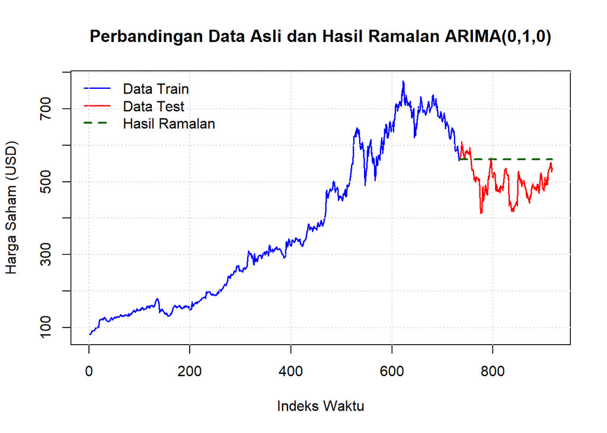

```r
plot(train, col = "blue", lwd = 1.5,
     main = "Perbandingan Data Asli dan Hasil Ramalan ARIMA(0,1,0)",
     ylab = "Harga Saham (USD)", xlab = "Indeks Waktu",
     xlim = c(1, n), ylim = range(y))
lines((n_train + 1):n, test, col = "red", lwd = 1.5)
lines((n_train + 1):n, ramalan_asli, col = "darkgreen", lwd = 2, lty = 2)
legend("topleft",
       legend = c("Data Train", "Data Test", "Hasil Ramalan"),
       col = c("blue", "red", "darkgreen"),
       lty = c(1, 1, 2), lwd = c(1.5, 1.5, 2), bty = "n")
grid()
```

## Keterangan Peramalan dan Evaluasi Model:

- Garis ramalan model $\text{ARIMA}(0,1,0)$ berbentuk datar karena nilai terakhir data *train* dijadikan acuan ramalan ke depan
- Nilai MAPE sebesar 13.68% menunjukkan kinerja ramalan masuk kategori baik (di bawah 20%)
- Model $\text{ARIMA}(0,1,0)$ sudah tepat dan untuk meramalkan harga saham Spotify

# Kesimpulan

1. Data penutupan harga saham Spotify 917 amatan awalnya memiliki tren kenaikan dan ragam yang belum stabil
2. Penanganan ketakstasioneran berhasil dilakukan melalui transformasi Box-Cox dan pembedaan pertama ($d = 1$).
3. Berdasarkan identifikasi PACF dan EACF, model terpilih adalah $\text{ARIMA}(0,1,0)$ karena memiliki nilai AIC terendah (-2810.730) dan parameter yang paling sederhana
4. Hasil uji diagnostik menunjukkan sisaan model telah memenuhi asumsi *white noise* (saling bebas), meskipun belum menyebar normal akibat karakteristik volatilitas data saham
5. Evaluasi peramalan pada data *test* menghasilkan nilai MAPE sebesar 13.68%, yang menunjukkan bahwa model $\text{ARIMA}(0,1,0)$ memiliki kinerja akurasi peramalan dalam kategori baik.